# Práctica de Deep Learning

## Organización de la práctica:

Esta práctica consta de tres partes, cada una de ellas es un *notebook* de `jupyter`, o sea, un documento como el que estás visualizando en este momento. Las partes son las siguientes:

- **Parte 0: Introducción al Deep Learning**. Es este *notebook*, preparatorio de la práctica mediante **realización guiada** en el que se tratarán:
  - Unas pinceladas a las matemáticas y la historia de las redes neuronales
  - Información sobre qué es y cómo instalar el software necesario para esta práctica: la distribución de python 3 [Anaconda](https://www.anaconda.com/distribution/), la librería de computación tensorial [PyTorch](https://pytorch.org/get-started/locally/) y la plataforma de notebooks `jupyter`.
  - Una introducción a la computación matricial en python con `pytorch`, que en muchas cosas se parece a matlab.
- **Parte 1: El Perceptrón Multicapa**. En esta parte se introduce el perceptrón multicapa (*Multi-Layer Perceptron* o MLP), la red neuronal más básica que podemos construir. Se verán detalladamente las pautas a seguir para crear, entrenar y evaluar una red neuronal utilizando la librería `pytorch`. Será una **realización guiada**, sin problemas a resolver.
- **Parte 2: Redes Neuronales Convolucionales**. Esta parte será la **entregable** de la práctica de redes. En ella veremos las redes neuronales convolucionales, que son la **herramienta más potente** que existe a día de hoy para el procesado de imagen. Se utilizan en coches autónomos, en la búsqueda de imágenes de google, diagnóstico de enfermedades, interpretación del lenguaje, y muchas más aplicaciones. Veremos las particularidades de estas redes y cómo se implementan cada una. La segunda parte de este *notebook* será el **problema a resolver**: crear y entrenar una red convolucional para la detección de dígitos escritos a mano.

La realización será autoguiada individual, siguiendo los *notebooks* que se proveen. Adicionalmente, el martes 19 a las 19:00 haremos una videotutoría para resolver dudas que puedan surgir con esta práctica.

## Evaluación de la práctica

La evaluación de esta práctica será mediante la **entrega del notebook** *Parte 2: Redes convolucionales* **con los problemas planteados resueltos**. Se entregará subiendo el fichero `*.ipynb`(cuaderno de jupyter) resuelto a través del campus virtual en la tarea especificada.

# Parte 0: Introducción

## ¿Qué es el Deep Learning?

Según la [Wikipedia](https://es.wikipedia.org/wiki/Aprendizaje_profundo), el *Deep Learning* o **aprendizaje profundo** es un conjunto de algoritmos de aprendizaje automático que intenta modelar abstracciones de alto nivel en datos utilizando arquitecturas computacionales que admiten transformaciones no lineales múltiples e iterativas de datos expresados en forma matricial o tensorial.

Esto se realiza mediante el uso de [redes neuronales](https://es.wikipedia.org/wiki/Red_neuronal_artificial) de múltiples capas en una grandísima variedad de arquitecturas. Podéis ver una charla sobre *deep learning*, redes neuronales y diferentes arquitecturas en este canal de youtube:

```python
from IPython.display import YouTubeVideo, HTML
YouTubeVideo('KqRnYGVjSNs', width=800, height=400)
# Ir a la URL: https://www.youtube.com/watch?v=KqRnYGVjSNs
```

[video not shown]

O una versión rápida de dicha introducción en 3 minutos:

```python
YouTubeVideo('4xaPxNPr43w', width=800, height=400)
# Ir a la URL: https://www.youtube.com/watch?v=4xaPxNPr43w
```

[video not shown]

# Material para la práctica

Para la realización de la práctica vamos a utilizar los siguientes **recursos**:

- Lenguaje de programación **Python 3** (recomendada la distribución [Anaconda](https://www.anaconda.com/distribution/))
- Formato de archivos: [Jupyter notebook](https://jupyter.org)
- Librería [PyTorch](https://pytorch.org/get-started/locally/)
- Bases de datos de imágenes MNIST handwritten digit database

En las siguientes secciones veremos qué es y cómo se instalan dichos componentes.

[figure not shown]

# Distribución Anaconda

[Anaconda](https://www.anaconda.com/distribution/) es una distribución del lenguaje de programación Python, orientada a la ciencia e ingeniería. Dispone de numerosas librerías que facilitan el trabajo como `numpy` (computación con arrays), `scipy` (estadística y procesado de señal) o `scikit-learn` (machine learning), entre otras muchas, convirtiéndola en la mayor **rival de Matlab**. Ésto, unido a que es **software libre** han hecho que su popularidad se haya visto incrementada en los últimos años, llegando a ser el lenguaje de programación más popular, incluso por encima de Java:

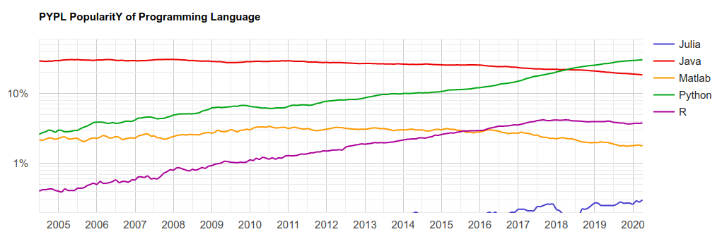

Fijáos en como la popularidad de matlab decrece conforme aumenta la de python, porque están muy relacionadas.

Para la instalación de Anaconda nos vamos a su [página oficial](https://www.anaconda.com/distribution/) o directamente lo descargamos en su versión para:

- Windows [Descarga](https://repo.anaconda.com/archive/Anaconda3-2020.02-Windows-x86_64.exe)
- MacOSX [Descarga](https://repo.anaconda.com/archive/Anaconda3-2020.02-MacOSX-x86_64.pkg)
- Linux [Descarga](https://repo.anaconda.com/archive/Anaconda3-2020.02-Linux-x86_64.sh)

Una vez descargado, realizamos la instalación de dicho paquete. Se detallan a continuación los pasos en cada sistema operativo.

### Windows

1. Ejecutar el archivo y "siguiente"
2. Leer la licencia y click en "I Agree".
3. Selecciona una instalación "Solo para mi" (a menos que vayas a compartir el ordenador con otros usuarios).
4. Selecciona una carpeta de destino para instalar Anaconda y haz clic en el botón Siguiente.
5. Elegir si desea añadir Anaconda a su variable de entorno PATH. Se recomienda **no** añadir Anaconda a la variable de entorno del PATH, ya que puede interferir con otros programas y en su lugar utilizarla abriendo el "Anaconda Navigator" desde el menú de inicio.
6. Elegir si desea registrar Anaconda como Python predeterminado. A menos que tengas instaladas o quieras ejecutar varias versiones de Anaconda o varias versiones de Python, dejar la casilla predeterminada marcada.
7. Haz clic en el botón Instalar. Si quieres ver los paquetes que Anaconda está instalando, haz clic en Mostrar detalles.
8. Haga clic en el botón Siguiente.
9. Os ofrecerá instalar PyCharm, un IDE para desarrollo en python. Nosotros no lo vamos a utilizar, así que si no queréis o no sabéis que es, click en "Siguiente".
10. Después de una instalación exitosa verá el cuadro de diálogo "Gracias por instalar Anaconda"

### MacOS

1. Haga doble clic en el archivo descargado y haga clic en continuar para iniciar la instalación.
2. Responda a las preguntas de las pantallas de Introducción, Léame y Licencia.
3. Haga clic en el botón Instalar para instalar Anaconda en su directorio ~/opt (recomendado):
4. En la pantalla de selección de destino, seleccione Instalar sólo para mí.
   - Si aparece el mensaje de error "No puede instalar Anaconda en esta ubicación", vuelva a seleccionar Instalar sólo para mí.
5. Haga clic en el botón de continuar.
6. Os ofrecerá instalar PyCharm, un IDE para desarrollo en python. Nosotros no lo vamos a utilizar, así que si no queréis o no sabéis que es, click en "Siguiente".
7. Después de una instalación exitosa verá el cuadro de diálogo "Gracias por instalar Anaconda"

### Linux

1. Abre la temrinal y navega hasta la carpeta de descargas
2. Introduce: `bash ~/Descargas/Anaconda3-2020.02-Linux-x86_64.sh` o el nombre del archivo descargado. Incluya el comando bash sin importar si está usando o no el shell Bash.
3. El instalador le pide "Para continuar el proceso de instalación, por favor revise el acuerdo de licencia". Haz clic en Intro para ver los términos de la licencia. Desplácese hasta la parte inferior de los términos de la licencia e introduzca "Sí" para aceptar.
4. El instalador le pedirá que haga clic en Intro para aceptar la ubicación de instalación predeterminada, en `/home/<usuario>/anaconda3`
5. El instalador pregunta: "¿Desea que el instalador inicialice Anaconda3 ejecutando conda init?" Recomendamos "sí". Si por error respondes no, puedes añadir anaconda al path con el paso siguiente:
   - primero ejecute `source /home/<usuario>/anaconda3/bin/activate` y luego ejecute `conda init`
6. El instalador termina y muestra "¡Gracias por instalar Anaconda3!"

## Verificar la instalación de Anaconda

- Windows: Haga clic en Inicio, busque o seleccione Anaconda Navigator en el menú.
- macOS: Haga clic en el Launchpad, seleccione el Anaconda Navigator. O, usa Cmd+Espacio para abrir Búsqueda y escribe "Navegador" para abrir el programa.
- Linux: Abre la terminal y escribe `conda list`, que listará todos los paquetes de Anaconda.

Para **solución de problemas**, consultar la [documentación de Anaconda](https://docs.anaconda.com/anaconda/install/).

# Jupyter Notebook

El **Jupyter Notebook** es una aplicación web de código abierto que permite crear y compartir documentos que contienen código en vivo, ecuaciones, visualizaciones y texto narrativo. Sus usos incluyen: limpieza y transformación de datos, simulación numérica, modelado estadístico, visualización de datos, aprendizaje automático y mucho más.

**Jupyter** se instala por defecto con Anaconda, de modo que solo es necesario lanzarlo.

## Abrir Jupyter

- Windows:
  1. Haga clic en Inicio, lance Anaconda Navigator en el menú.
  2. Seleccione "Jupyter.
- macOS:
  1. Haga clic en el Launchpad, seleccione el Anaconda Navigator.
  2. Lanza "Jupyter notebook"
- Linux:
  1. Abre la terminal
  2. Escribe `jupyter notebook`

En todos los casos se abrirá una ventana similar a la siguiente, en la que podrás navegar por el árbol de directorios y cargar los notebooks de ipython que quieras. Si quieres probar, navega hasta la carpeta donde hayas descargado esta práctica y selecciona el archivo `00 Practica Deep Learning - Introducción.ipynb`, y podrás ver este mismo fichero en su versión interactiva.

[figure not shown]

[figure not shown]

# PyTorch

**PyTorch** es un paquete de Python diseñado para realizar cálculos numéricos haciendo uso de la programación de tensores. Además permite su ejecución en GPU para acelerar los cálculos.

Normalmente PyTorch es usado tanto para sustituir numpy y procesar los cálculos en GPU como para la investigación y desarrollo en el campo del machine learning, centrado principalmente en el desarrollo de redes neuronales.

## Alternativas a PyTorch:

En la actualidad disponemos de varias alternativas a PyTorch en su aplicación al machine learning, algunas de las más conocidas son:

- **Tensorflow**: fue desarrollado por Google Brain Team. Es software libre diseñado para computación numérica mediante grafos.
- **Theano**: es una librería de python que te permite definir, optimizar y evaluar expresiones matemáticas que implican cálculos con arrays multidimensionales de forma eficiente.
- **Keras**: es una API de alto nivel para el desarrollo de redes neuronales escrita en Python. Utiliza otras librerías de forma interna como son Tensorflow, CNTK y Theano. Fue desarrollado con el propósito de facilitar y agilizar el desarrollo y la experimentación con redes neuronales. Hoy día se distribuye junto con **Tensorflow**.

Mediante un análisis de las tendencias en Google Trends, se puede observar que PyTorch no deja de crecer, mientras que Keras y Tensorflow llevan unos meses a la baja. Aún así, Tensorflow sigue siendo el framework más popular, pero desde mi punto de vista es más complejo de dominar, y depende mucho de su API, mientras que la programación en PyTorch es más intuitiva, por lo que es la librería elegida para esta práctica.

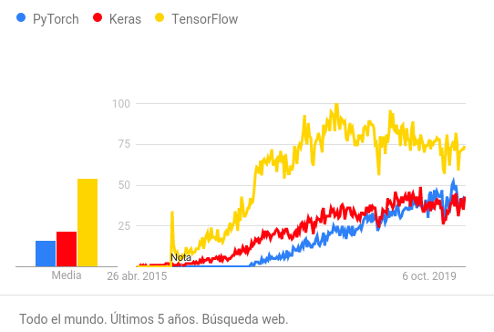

## Instalación de Pytorch

Para la instalación de pytorch, tenemos que lanzar la consola de **Anaconda**:

- Windows: Haga clic en Inicio, busque o seleccione Anaconda Prompt en el menú.
- MacOS y Linux: Abrir terminal.

Ahora ve a la [página de instalación de pytorch](https://pytorch.org/get-started/locally/) y selecciona las características de tu instalación, que serán probablemente las que aparezcan por defecto:

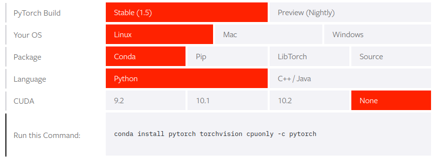

En PyTorch Build usaremos la version *Stable*, en el Package pondremos *Conda* para instalarlo con anaconda, y Language será *Python*. En cuanto al OS seleccionar Linux, Mac o Windows en función de vuestro sistema operativo y finalmente en CUDA pondremos *None*, a menos que tengáis una tarjeta gráfica de Nvidia (en ese caso es más complejo puesto que hay que instalar las librerías CUDA y CuDNN, así como los drivers de Nvidia).

Copiar el texto que aparece al lado de "Run this Command" y pegar en la terminal o el "Anaconda Prompt" en windows, dar siguiente y ya estará instalado.

## Verificar la instalación

Para verificar si se ha instalado, abrimos una terminal de python:

- Windows y MacOS: Abre Anaconda Navigator y lanza `qtconsole`.
- Linux: Abre la terminal y escribe `ipython`.

Y en la consola de Python escribimos:

```
from __future__ import print_function
import torch
x = torch.rand(5, 3)
print(x)
```

Si todo funciona correctamente, ya tenemos todos los requisitos necesarios para realizar la práctica.

## ¿Cómo funciona pytorch?

Vamos a ver un tutorial rápido del tipo de datos de pytorch y cómo trabaja internamente esta librería. Para esto tendrás que haber seguido correctamente todos los pasos anteriores. Para esto necesitas la **versión interactiva del notebook**.

Para esta sección:

- **Abre Jupyter** (consultar arriba)
- Navega hasta el notebook `00 Práctica Deep Learning - Introducción.ipynb` y ábrelo.
- Baja hasta esta sección.

### Algunas diferencias entre Matlab y Python

Pero antes de nada os cuento algunas diferencias entre matlab y python:

- Python es un **lenguaje de propósito general** mientras que matlab es un lenguaje **específico para ciencia e ingeniería**. Esto no es ni bueno ni malo; matlab es más fácil de utilizar para ingeniería sin preparación, pero python es más versátil.
- Debido a ello, **Matlab carga automáticamente todas las funciones** mientras que en Python, **hay que cargar las librerías que vamos a utilizar**. Esto hace que usar funciones en matlab sea más sencillo (dos letras menos que escribir), pero a costa de que es más difícil gestionar la memoria, y los nombres de funciones se puden superponer. Supon que `A` es una matriz. Para hacer la pseudoinversa, en matlab hacemos:

```
pinv(A)
```

- en python tenemos que cargar la librería:

  ```
  import scipy as sp
  sp.pinv(A)
  ```

- Esto genera una cosa llamada **espacio de nombres**, en el que las funciones de cada librería van precedidas por su abreviatura (si importamos con `import x as y`) o el propio nombre si usamos `import torch`, `torch.tensor()`, mientras que en matlab basta con llamar a la función. Por ejemplo, cuando en matlab escribimos:
  - `vector = [1, 2, 3]`
- en python+pytorch necesitamos especificar que es un tensor (un array multidimensional):
  - `vector = torch.tensor([1,2,3])`

Hay más diferencias, pero la idea de cargar librerías y el espacio de nombres suelen ser las más complejas para los principiantes.

### Realización guiada

Vamos a cargar la librería con `import torch` y ver que podemos, por ejemplo, construir una matriz de 5x3 aleatoria. Para ejecutar una celda, basta con seleccionarla (bien con las flechas del teclado, bien con el ratón) y pulsando `Ctrl+Enter` (o bien pulsando "Run" en la barra superior).

```python
import torch
x = torch.rand(5, 3)
print(x)
```

```
tensor([[0.2472, 0.7132, 0.1375],
        [0.7200, 0.2924, 0.3832],
        [0.4341, 0.3518, 0.9204],
        [0.3709, 0.2253, 0.6080],
        [0.9817, 0.5234, 0.2136]])
```

O una matriz de ceros:

```python
x = torch.zeros(5, 3, dtype=torch.long)
print(x)
```

```
tensor([[0, 0, 0],
        [0, 0, 0],
        [0, 0, 0],
        [0, 0, 0],
        [0, 0, 0]])
```

O a partir de unos datos dados, y podemos mostrarla con `print`, pero también acceder a sus características, como el tamaño de la matriz:

```python
x = torch.tensor([[5.5, 3, 3],[2,1, 5], [3,4,2],[7,6,5],[2,1,2]])
print(x)
print(x.shape)
```

```
tensor([[5.5000, 3.0000, 3.0000],
        [2.0000, 1.0000, 5.0000],
        [3.0000, 4.0000, 2.0000],
        [7.0000, 6.0000, 5.0000],
        [2.0000, 1.0000, 2.0000]])
torch.Size([5, 3])
```

Con tensores se puede operar de forma normal:

```python
y = torch.rand(5, 3)
print(x + y)
```

```
tensor([[6.3343, 3.7080, 3.9404],
        [2.3815, 1.0040, 5.7915],
        [3.0152, 4.8507, 2.5595],
        [7.2281, 6.1131, 5.3825],
        [2.3290, 1.9387, 2.1796]])
```

Pero OJO CUIDAO, tienen que ser del mismo tamaño, si no, va a dar error:

```python
y = torch.rand(2,3)
print(x+y)
```

```
---------------------------------------------------------------------------
RuntimeError                              Traceback (most recent call last)
<ipython-input-7-42fe1c64fd19> in <module>
      1 y = torch.rand(2,3)
----> 2 print(x+y)

RuntimeError: The size of tensor a (5) must match the size of tensor b (2) at non-singleton dimension 0
```

```python
print(x[:, 1])
```

```
tensor([3., 1., 4., 6., 1.])
```

Otra característica que nos será de mucha utilidad es cambiar la forma de la matriz, que en otros lenguajes se conoce como `reshape`, y aquí es un método del objeto tensor llamado `view()`:

```python
x = torch.randn(4, 4)
y = x.view(16)
z = x.view(-1, 8)  # the size -1 is inferred from other dimensions
print(x.size(), y.size(), z.size())
```

```
torch.Size([4, 4]) torch.Size([16]) torch.Size([2, 8])
```

Podemos operar con tensores y valores escalares:

```python
y = x + 2
print(y)
```

```
tensor([[2.9619, 1.8762, 2.1108, 2.6227],
        [2.4012, 2.8760, 0.8042, 1.2621],
        [1.2319, 2.2896, 1.6425, 3.2375],
        [3.3435, 2.0807, 3.2948, 0.7555]])
```

Y también podemos definir funciones que realicen estas operaciones que apliquemos a los diferentes tensores:

```python
def modulo(x,y):
    aux = x**2 + y**2
    salida = torch.sqrt(aux)
    return salida

print(modulo(x,y))
```

```
tensor([[3.1142, 1.8803, 2.1137, 2.6956],
        [2.4345, 3.0064, 1.4411, 1.4620],
        [1.4517, 2.3079, 1.6809, 3.4660],
        [3.6033, 2.0823, 3.5401, 1.4559]])
```

Y, una parte fundamental es que pytorch conserva memoria de las operaciones realizadas en un vector:

```python
x = torch.ones(2, 2, requires_grad=True)
y = x + 2
print(y)
```

```
tensor([[3., 3.],
        [3., 3.]], grad_fn=<AddBackward0>)
```

La propiedad `grad_fn` será fundamental en el entrenamiento de redes neuronales, ya que guarda el gradiente de la operación o función que se haya aplicado a los datos. Esto se conserva a traves de todas las operaciones:

```python
z = y * y * 3
out = z.mean()

print(z, out)
```

```
tensor([[27., 27.],
        [27., 27.]], grad_fn=<MulBackward0>) tensor(27., grad_fn=<MeanBackward0>)
```

O incluso llevan cuenta de las operaciones realizadas con funciones:

```python
print(modulo(x,y))
```

```
tensor([[3.1623, 3.1623],
        [3.1623, 3.1623]], grad_fn=<SqrtBackward>)
```

Para calcular el gradiente a lo largo de estas operaciones se utiliza la función `.backward()`, que realiza la propagación del gradiente hacia atrás. Podemos mostrar el gradiente $\frac{\partial out}{\partial x}$ con la propiedad `x.grad`, así que lo vemos:

```python
out.backward()
print(x.grad)
```

```
tensor([[4.5000, 4.5000],
        [4.5000, 4.5000]])
```

Habrá aquí una matriz de 2x2 con valores 4.5. Si llamamos el tensor de salida $o$, tenemos que: $$ o = \frac{1}{4} \sum_iz_i, \quad z_i = 3(x_i + 2)^2$$ Así que $z_i|_{x_i=1} = 27$. Entonces, la $\frac{\partial o}{\partial x_i} = \frac{3}{2}(x_i+2)$ y $\frac{\partial o}{\partial x_i} |_{x_i=1} = \frac{9}{2} = 4.5$

Gracias a esto, y a las matemáticas del algoritmo de propagación hacia atrás (*backpropagation*, ver video de introducción a la práctica), se pueden actualizar los pesos en función de una función de pérdida en las redes neuronales. Se puede activar y desactivar el cálculo del gradiente con la expresión `torch.no_grad()`.

```python
print(x.requires_grad)
print((x ** 2).requires_grad)

with torch.no_grad():
    print((x ** 2).requires_grad)
```

```
True
True
False
```

En la próxima sección, `01 Práctica Deep Learning - Perceptrón Multicapa.ipynb`, veremos como se construye y se entrena nuestra primera red neuronal utilizando estas características de pytorch.